# STA 141A Final Project

Lucky Chong

2025-03-17

# Abstract

This project is based on a research by Steinmetz et. al, where he examined mice performance in a behavioral task. The data was collected on various factors such as brain areas, neural activity, and stimuli. The goal of this dataset is to explore the data, extract meaningful insights, and integrate the findings to develop a predictive model. This integrated data is used to build a prediction model in order to predict if the mice had a successful trial. Further research and analysis for this research will help improve the accuracy of the predicted model and any other additional questions that are left unanswered.

# Introduction

The study takes place for 10 mice across 39 separate sessions; however, in this experiment, we will be only analyzing 4 mice and 18 sessions. For each trial of the session, the mice were presented with images to their left and right, as well as both their left and their right, or neither their left nor their right. Images were presented at one of four contrast levels: 0, 0.25, 0.50 and 1. A water reward was used in order to help ensure engagement of the mice in the task, and a white noise was presented when mice choice was incorrect. Feedback after each trial was recorded, with a 1 recorded if the mice turned the wheel toward the higher contrast or in the case of no image, kept the wheel still. If unsuccessful, the water reward was held back and a -1 was recorded for feedback.

This project will analyze data using R from just four of the ten mice across 18 of the 39 sessions. This project seeks to build a predictive model that will predict the outcome of each trial, whether the trial was a success or a failure.

# **Exploratory Data Analysis**

To tackle this dataset, we will start looking at the data for each session and analyze patterns in the trials in order to develop a deeper understanding of this research. This will allow us to comprehend the trends that are ongoing in this dataset.

[figure not shown]

```r
session <- list()
for(i in 1:18) {
  session[[i]] <- readRDS(paste0("session", i, ".rds"))
}

get_trail_data <- function(session_id, trial_id) {
  spikes <- session[[session_id]]$spks[[trial_id]]
  if (any(is.na(spikes))) {
    print("Value missing in trial", trial_id, "of session", session_id)
  }

  trail_tibble <- tibble("neuron_spike" = rowSums(spikes)) %>%
    add_column("brain_area" = session[[session_id]]$brain_area) %>%
    group_by(brain_area) %>%
    summarize(region_sum_spike = sum(neuron_spike),
              region_count = n(),
              region_mean_spike = mean(neuron_spike),
              .groups = "drop") %>%
    add_column("session_id" = session_id,
               "trial_id" = trial_id,
               "contrast_left" = session[[session_id]]$contrast_left[trial_id],
               "contrast_right" = session[[session_id]]$contrast_right[trial_id],
               "feedback_type" = session[[session_id]]$feedback_type[trial_id])

  return(trail_tibble)
}

trial_data <- bind_rows(lapply(1:18, function(session_id) {
  trials <- seq_along(session[[session_id]]$spks)
  bind_rows(lapply(trials, function(trial_id) {
    get_trail_data(session_id, trial_id)
  }))
}))

df <- trial_data %>%
  select(session_id, trial_id, feedback_type, contrast_left, contrast_right)

df_summary <- df %>%
  group_by(feedback_type) %>%
  summarise(n = n(), .groups = 'drop')

ggplot(df, aes(x = contrast_left, fill = feedback_type)) +
  geom_histogram(binwidth = 0.05, alpha = 0.6, position = "identity") +
  geom_histogram(data = df, aes(x = contrast_right, fill = feedback_type),
                 binwidth = 0.05, alpha = 0.6, position = "identity") +
  scale_fill_manual(values = c("Success" = "lightpink", "Failure" = "skyblue")) +
  labs(title = "Contrast Distribution for Success vs Failure",
       x = "Contrast Level", y = "Count", fill = "Feedback Type") +
  theme_minimal()
```

The data is neural spike activity recorded during trials in an experiment session. There are several trials in each session where neural activity (spikes) from various brain regions is recorded. The objective appears to be to compare how neural activity changes according to varying experimental conditions, specifically the contrast levels and types of feedback given during each trial.

```r
df_cleaned <- df %>%
  filter(!is.na(contrast_left) & !is.na(contrast_right))

sum(is.na(df_cleaned$contrast_left))
```

```
## [1] 0
```

```r
sum(is.na(df_cleaned$contrast_right))
```

```
## [1] 0
```

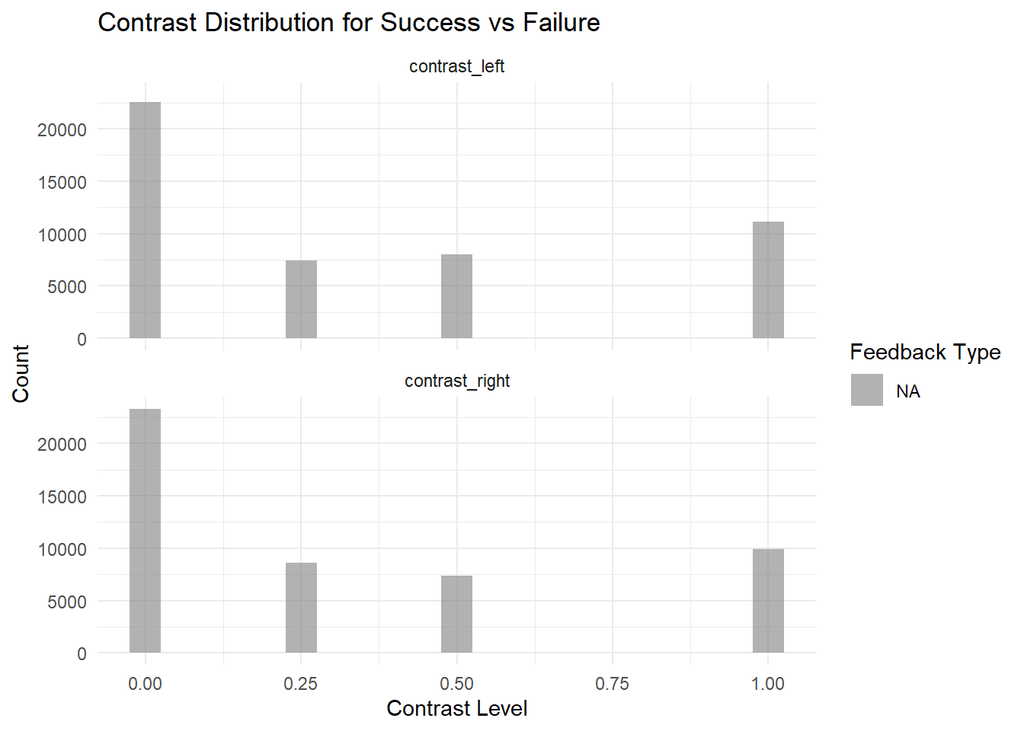

```r
df_cleaned$feedback_type <- factor(df_cleaned$feedback_type, levels = c("Success", "Failure"))

df_long <- df_cleaned %>%
  pivot_longer(cols = c(contrast_left, contrast_right),
               names_to = "contrast_type",
               values_to = "contrast_value")

ggplot(df_long, aes(x = contrast_value, fill = feedback_type)) +
  geom_histogram(binwidth = 0.05, alpha = 0.6, position = "identity") +
  scale_fill_manual(values = c("Success" = "lightpink", "Failure" = "skyblue")) +
  labs(title = "Contrast Distribution for Success vs Failure",
       x = "Contrast Level", y = "Count", fill = "Feedback Type") +
  theme_minimal() +
  facet_wrap(~contrast_type, ncol = 1)
```

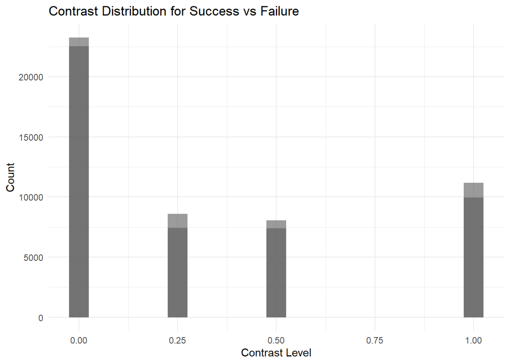

```r
session <- list()
for(i in 1:18) {
  session[[i]] <- readRDS(paste0("session", i, ".rds"))
}



ggplot(df, aes(x = contrast_left, fill = feedback_type)) +
  geom_histogram(binwidth = 0.05, alpha = 0.6, position = "identity") +
  geom_histogram(data = df, aes(x = contrast_right, fill = feedback_type),
                 binwidth = 0.05, alpha = 0.6, position = "identity") +
  labs(title = "Contrast Distribution for Success vs Failure",
       x = "Contrast Level", y = "Count", fill = "Feedback Type") +
  theme_minimal()
```

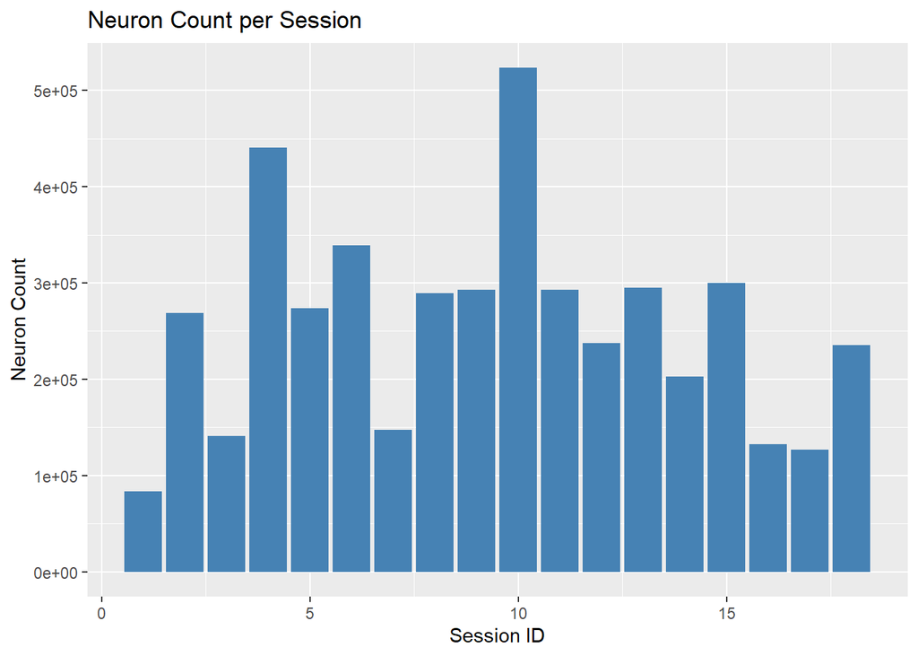

```r
session <- list()
for(i in 1:18) {
  session[[i]] <- readRDS(paste0("session", i, ".rds"))
}

get_trail_data <- function(session_id, trial_id) {
  spikes <- session[[session_id]]$spks[[trial_id]]
  if (any(is.na(spikes))) {
    print("Value missing in trial", trial_id, "of session", session_id)
  }

  trail_tibble <- tibble("neuron_spike" = rowSums(spikes)) %>%
    add_column("brain_area" = session[[session_id]]$brain_area) %>%
    group_by(brain_area) %>%
    summarize(region_sum_spike = sum(neuron_spike),
              region_count = n(),
              region_mean_spike = mean(neuron_spike),
              .groups = "drop") %>%
    add_column("session_id" = session_id,
               "trial_id" = trial_id,
               "contrast_left" = session[[session_id]]$contrast_left[trial_id],
               "contrast_right" = session[[session_id]]$contrast_right[trial_id],
               "feedback_type" = session[[session_id]]$feedback_type[trial_id])

  return(trail_tibble)
}

trial_data <- bind_rows(lapply(1:18, function(session_id) {
  trials <- seq_along(session[[session_id]]$spks)
  bind_rows(lapply(trials, function(trial_id) {
    get_trail_data(session_id, trial_id)
  }))
}))

full_functional_tibble <- trial_data

neuron_count_summary <- full_functional_tibble %>%
  group_by(session_id) %>%
  summarise(neuron_count = sum(region_count))

ggplot(neuron_count_summary, aes(x = session_id, y = neuron_count)) +
  geom_bar(stat = "identity", fill = "steelblue") +
  labs(title = "Neuron Count per Session", x = "Session ID", y = "Neuron Count")
```

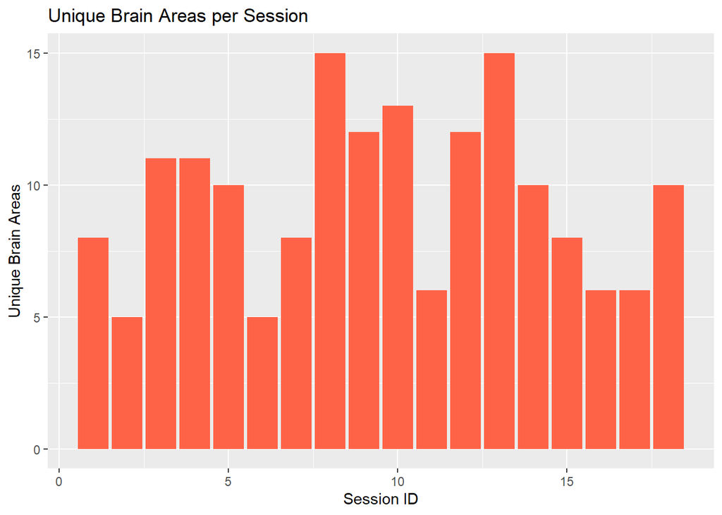

```r
brain_area_summary <- full_functional_tibble %>%
  group_by(session_id) %>%
  summarise(unique_areas = n_distinct(brain_area))

ggplot(brain_area_summary, aes(x = session_id, y = unique_areas)) +
  geom_bar(stat = "identity", fill = "tomato") +
  labs(title = "Unique Brain Areas per Session", x = "Session ID", y = "Unique Brain Areas")
```

The objective here is to compare the number of unique brain regions used in each session of an experiment. The data is grouped by session, and the number of unique brain regions across the group is calculated. The bar plot generated shows the number of unique brain regions per session, with session IDs on the x-axis and the number of unique brain regions on the y-axis.

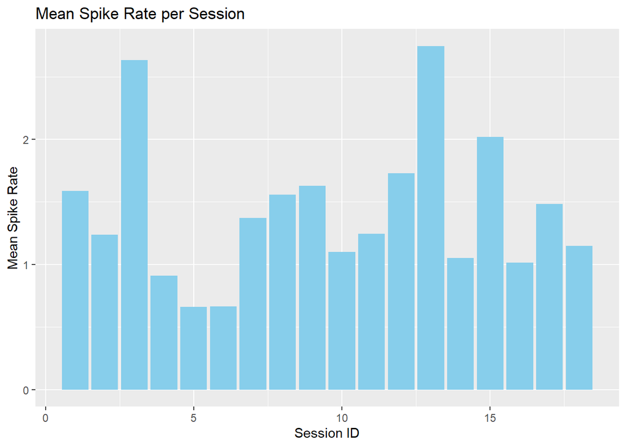

```r
mean_spike_summary <- full_functional_tibble %>%
  group_by(session_id) %>%
  summarise(mean_spike_rate = mean(region_mean_spike, na.rm = TRUE))

ggplot(mean_spike_summary, aes(x = session_id, y = mean_spike_rate)) +
  geom_bar(stat = "identity", fill = "skyblue") +
  labs(title = "Mean Spike Rate per Session", x = "Session ID", y = "Mean Spike Rate")
```

The analysis highlights the neural activity for each session, with a higher mean spike rate reflecting greater neural firing or activity within the areas of the brain in a session.

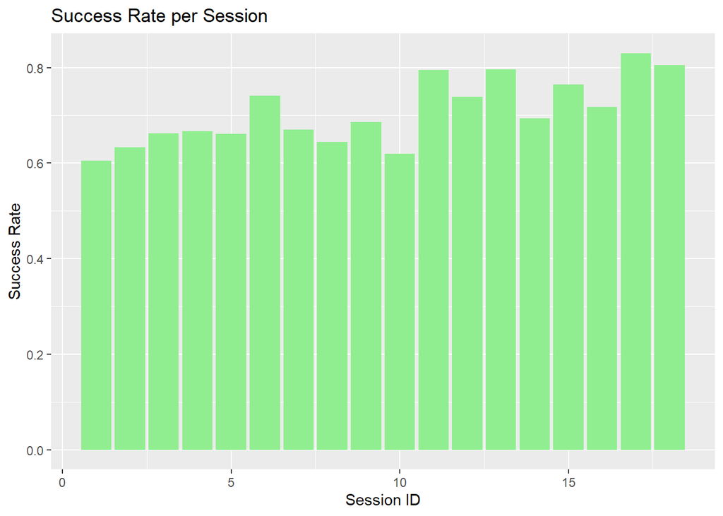

```r
success_rate_summary <- full_functional_tibble %>%
  group_by(session_id) %>%
  summarise(success_rate = mean(feedback_type == 1, na.rm = TRUE))

ggplot(success_rate_summary, aes(x = session_id, y = success_rate)) +
  geom_bar(stat = "identity", fill = "lightgreen") +
  labs(title = "Success Rate per Session", x = "Session ID", y = "Success Rate")
```

Higher success rates reflect better performance or better conditions during those sessions. Visualization via this data helps identify trends or patterns of performance, indicating if there were better results for some sessions.

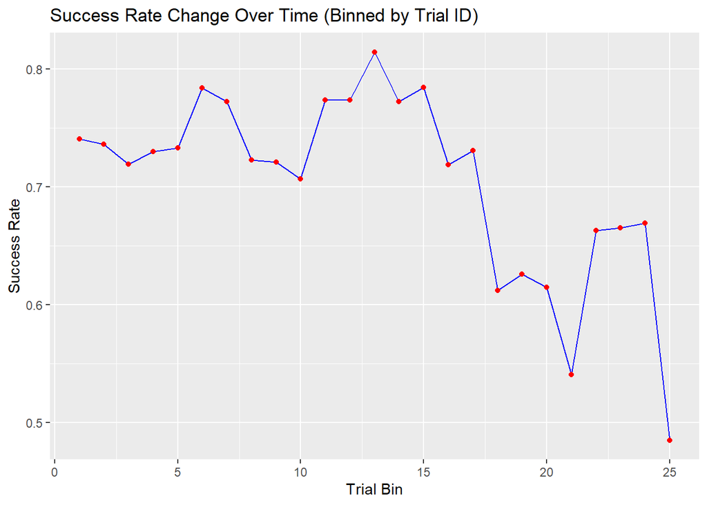

```r
trial_bin_summary <- full_functional_tibble %>%
  mutate(trial_bin = ntile(trial_id, 25)) %>%
  group_by(trial_bin) %>%
  summarise(success_rate = mean(feedback_type == 1, na.rm = TRUE))

ggplot(trial_bin_summary, aes(x = trial_bin, y = success_rate)) +
  geom_line(color = "blue") +
  geom_point(color = "red") +
  labs(title = "Success Rate Change Over Time (Binned by Trial ID)", x = "Trial Bin", y = "Success Rate")
```

The y-axis would show the success rate for each bin, while the x-axis would be used to represent the trial bins or different portions of the experiment. The graph would be shaded blue for the line and red for the points to provide a very good glimpse of the trend in successes with time.

```r
colnames(full_functional_tibble)
```

```
## [1] "brain_area"        "region_sum_spike"  "region_count"
## [4] "region_mean_spike" "session_id"        "trial_id"
## [7] "contrast_left"     "contrast_right"    "feedback_type"
```

```r
sum(is.na(full_functional_tibble$contrast_right))
```

```
## [1] 0
```

```r
sum(is.na(full_functional_tibble$contrast_left))
```

```
## [1] 0
```

```r
full_functional_tibble_clean <- full_functional_tibble %>%
  filter(!is.na(contrast_right) & !is.na(contrast_left))

subset_data <- full_functional_tibble_clean[, c("contrast_right", "contrast_left")]

summary(subset_data)
```

```
##  contrast_right   contrast_left
##  Min.   :0.0000   Min.   :0.0000
##  1st Qu.:0.0000   1st Qu.:0.0000
##  Median :0.2500   Median :0.2500
##  Mean   :0.3209   Mean   :0.3467
##  3rd Qu.:0.5000   3rd Qu.:0.5000
##  Max.   :1.0000   Max.   :1.0000
```

This code revolves around cleaning up the dataset and summarizing contrast values for the left and right contrasts. The first step checks for missing contrast_right and contrast_left values by using the sum(is.na()) function. If missing, they are then removed in the second step. Once the data is cleaned, a subset of the correct columns (contrast_right and contrast_left) is taken, and these two columns are summarized using the summary() function. This provides valuable statistics like the minimum, maximum, mean, and median of both contrasts. The output gives details about the range and distribution of the contrast values within the dataset and helps to establish if the contrasts are within valid limits and if further data reprocessing is required.

```r
n.session=length(session)

meta <- tibble(
  Mouse_name = rep('name',n.session),
  Date_exp =rep('dt',n.session),
  Number_of_brain_areas = rep(0,n.session),
  Number_of_neurons = rep(0,n.session),
  Number_of_trials = rep(0,n.session),
  Overall_success_rate = rep(0,n.session),
)


for(i in 1:n.session){
  tmp = session[[i]];
  meta[i,1]=tmp$mouse_name;
  meta[i,2]=tmp$date_exp;
  meta[i,3]=length(unique(tmp$brain_area));
  meta[i,4]=dim(tmp$spks[[1]])[1];
  meta[i,5]=length(tmp$feedback_type);
  meta[i,6]=mean(tmp$feedback_type+1)/2;
}

unique_brain_areas <- c()
for(i in 1:n.session){
  unique_brain_areas <- c(unique_brain_areas ,unique(session[[i]]$brain_area))
  unique_brain_areas <-unique(unique_brain_areas)
}

length(unique_brain_areas)
```

```
## [1] 62
```

```r
kable(meta, format = "html", caption= "Mice Session Overview", col.names = gsub("[_]", " ", names(meta)), table.attr = "class='table table-striped'",digits=2)
```

Mice Session Overview

| Mouse name | Date exp | Number of brain areas | Number of neurons | Number of trials | Overall success rate |
| --- | --- | --- | --- | --- | --- |
| Cori | 2016-12-14 | 8 | 734 | 114 | 0.61 |
| Cori | 2016-12-17 | 5 | 1070 | 251 | 0.63 |
| Cori | 2016-12-18 | 11 | 619 | 228 | 0.66 |
| Forssmann | 2017-11-01 | 11 | 1769 | 249 | 0.67 |
| Forssmann | 2017-11-02 | 10 | 1077 | 254 | 0.66 |
| Forssmann | 2017-11-04 | 5 | 1169 | 290 | 0.74 |
| Forssmann | 2017-11-05 | 8 | 584 | 252 | 0.67 |
| Hench | 2017-06-15 | 15 | 1157 | 250 | 0.64 |
| Hench | 2017-06-16 | 12 | 788 | 372 | 0.69 |
| Hench | 2017-06-17 | 13 | 1172 | 447 | 0.62 |
| Hench | 2017-06-18 | 6 | 857 | 342 | 0.80 |
| Lederberg | 2017-12-05 | 12 | 698 | 340 | 0.74 |
| Lederberg | 2017-12-06 | 15 | 983 | 300 | 0.80 |
| Lederberg | 2017-12-07 | 10 | 756 | 268 | 0.69 |
| Lederberg | 2017-12-08 | 8 | 743 | 404 | 0.76 |
| Lederberg | 2017-12-09 | 6 | 474 | 280 | 0.72 |
| Lederberg | 2017-12-10 | 6 | 565 | 224 | 0.83 |
| Lederberg | 2017-12-11 | 10 | 1090 | 216 | 0.81 |

```r
summary(meta$Number_of_trials)
```

```
##    Min. 1st Qu.  Median    Mean 3rd Qu.    Max.
##   114.0   249.2   261.0   282.3   330.0   447.0
```

```r
summary(meta$Number_of_neurons)
```

```
##    Min. 1st Qu.  Median    Mean 3rd Qu.    Max.
##   474.0   707.0   822.5   905.8  1086.8  1769.0
```

```r
summary(meta$Number_of_brain)
```

```
## Length  Class   Mode
##      0   NULL   NULL
```

The code aggregates significant metadata from 18 sessions in the session list. The code starts by setting up a tibble meta to store data such as the mouse name, experiment date, number of unique brain areas, neurons, trials, and overall success rate per session. The loop iterates through each session, and the relevant data are pulled and calculated. It also retrieves all unique brain areas from all sessions and provides the total different number of areas. This code gives you an overview of the experimental data.

# Data Integration

[output not shown]

[output cut: 58 more lines]

[output not shown]

```
## contrast_left exists:  TRUE
```

```
## contrast_right exists:  TRUE
```

```
## spks_mean exists:  TRUE
```

```
## spks_sd exists:  TRUE
```

```
## Importance of components:
##                           PC1    PC2    PC3     PC4
## Standard deviation     1.3678 1.0178 0.9716 0.38639
## Proportion of Variance 0.4677 0.2590 0.2360 0.03732
## Cumulative Proportion  0.4677 0.7267 0.9627 1.00000
```

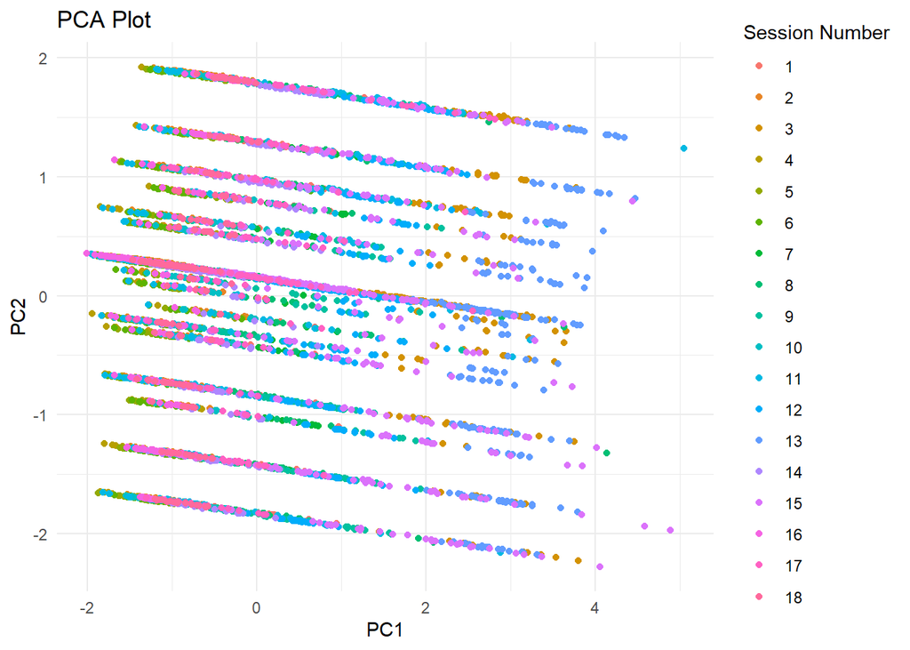

A scatter plot is generated to show the first two principal components (PC1 and PC2) by different session numbers, providing an overall impression of how sessions differ based on the principal components.

# Predictive Modeling

```r
full_functional_tibble <- full_functional_tibble %>%
  mutate(label = ifelse(feedback_type == 1, 1, 0))

predictive_dat <- full_functional_tibble %>%
  select(session_id, trial_id, contrast_left, contrast_right,
         region_sum_spike, region_count, region_mean_spike, brain_area, label)

brain_area_features <- full_functional_tibble %>%
  select(session_id, trial_id, brain_area, region_mean_spike) %>%
  pivot_wider(names_from = brain_area,
              values_from = region_mean_spike,
              values_fill = 0)

X_df <- full_functional_tibble %>%
  select(session_id, trial_id, contrast_left, contrast_right) %>%
  distinct() %>%
  left_join(brain_area_features, by = c("session_id", "trial_id"))

X <- X_df %>%
  select(-session_id, -trial_id) %>%
  as.matrix()

label <- full_functional_tibble %>%
  select(session_id, trial_id, feedback_type) %>%
  distinct() %>%
  arrange(session_id, trial_id) %>%
  pull(feedback_type)

set.seed(123)
trainIndex <- createDataPartition(label, p = .8,
                                  list = FALSE,
                                  times = 1)
train_df <- predictive_dat[trainIndex, ]
train_X <- X[trainIndex,]
test_df <- predictive_dat[-trainIndex, ]
test_X <- X[-trainIndex,]

train_label <- label[trainIndex]
test_label <- label[-trainIndex]

train_label <- ifelse(train_label == 1, 1, 0)
test_label <- ifelse(test_label == 1, 1, 0)

xgb_model <- xgboost(data = train_X, label = train_label, objective = "binary:logistic", nrounds=10)
predictions <- predict(xgb_model, newdata = test_X)
predicted_labels <- as.numeric(ifelse(predictions > 0.5, 1, 0))
accuracy <- mean(predicted_labels == test_label)
accuracy
```

```
## [1] 0.7204724
```

```r
conf_matrix <- confusionMatrix(as.factor(predicted_labels), as.factor(test_label))
conf_matrix$table
```

```
##           Reference
## Prediction   0   1
##          0  28  15
##          1 269 704
```

```r
auroc <- roc(test_label, predictions)
auroc
```

```
##
## Call:
## roc.default(response = test_label, predictor = predictions)
##
## Data: predictions in 297 controls (test_label 0) < 719 cases (test_label 1).
## Area under the curve: 0.7171
```

Thie code divides data into a training (80%) and a test (20%) set, preparing labels for binary classification. The program fits a model based on XGBoost with logistic regression, makes predictions on the test set, and verifies model accuracy. A confusion matrix is established to establish performance, and the Area Under the ROC Curve (AUROC) is found to establish the ability of the model to distinguish between classes.